# (tentar) Explicar a votação de Deputados usando Regressão Linear

# Os Dados

```r
eleicoes_data <- readr::read_csv(
  here::here('data/eleicoes_2006_e_2010.csv'),
  local=readr::locale("br"),
  col_types = cols(
    ano = col_integer(),
    sequencial_candidato = col_character(),
    quantidade_doacoes = col_integer(),
    quantidade_doadores = col_integer(),
    total_receita = col_double(),
    media_receita = col_double(),
    recursos_de_outros_candidatos.comites = col_double(),
    recursos_de_pessoas_fisicas = col_double(),
    recursos_de_pessoas_juridicas = col_double(),
    recursos_proprios = col_double(),
    `recursos_de_partido_politico` = col_double(),
    quantidade_despesas = col_integer(),
    quantidade_fornecedores = col_integer(),
    total_despesa = col_double(),
    media_despesa = col_double(),
    votos = col_integer(),
    .default = col_character()))
```

```r
eleicoes_data %>%
  mutate(nome = toupper(nome),
         sexo = toupper(sexo),
         grau = toupper(grau),
         nome = toupper(nome),
         cargo = toupper(cargo),
         ocupacao = toupper(ocupacao),
         partido = toupper(partido),
         estado_civil = toupper(estado_civil)) %>%
  mutate(uf = as.factor(uf),
         nome = as.factor(nome),
         sexo = as.factor(sexo),
         grau = as.factor(grau),
         nome = as.factor(nome),
         cargo = as.factor(cargo),
         partido = as.factor(partido),
         ocupacao = as.factor(ocupacao),
         estado_civil = as.factor(estado_civil),
         sequencial_candidato = as.numeric(sequencial_candidato)) %>%
  mutate(total_recursos = recursos_de_pessoas_fisicas +
                            recursos_de_outros_candidatos.comites +
                            recursos_de_pessoas_juridicas +
                            recursos_proprios) -> eleicoes_data

eleicoes_2006 <- eleicoes_data %>% filter(ano == 2006)
eleicoes_2010 <- eleicoes_data %>% filter(ano == 2010)

eleicoes_data %>%
  glimpse()
```

```
## Observations: 7,476
## Variables: 25
## $ ano                                   <int> 2006, 2006, 2006, 2006, ...
## $ sequencial_candidato                  <dbl> 10001, 10002, 10002, 100...
## $ nome                                  <fct> JOSÉ LUIZ NOGUEIRA DE SO...
## $ uf                                    <fct> AP, RO, AP, MS, RO, PI, ...
## $ partido                               <fct> PT, PT, PT, PRONA, PT, P...
## $ quantidade_doacoes                    <int> 6, 13, 17, 6, 48, 6, 14,...
## $ quantidade_doadores                   <int> 6, 13, 16, 6, 48, 6, 7, ...
## $ total_receita                         <dbl> 16600.00, 22826.00, 1581...
## $ media_receita                         <dbl> 2766.67, 1755.85, 9301.2...
## $ recursos_de_outros_candidatos.comites <dbl> 0.00, 6625.00, 2250.00, ...
## $ recursos_de_pessoas_fisicas           <dbl> 9000.00, 15000.00, 34150...
## $ recursos_de_pessoas_juridicas         <dbl> 6300.00, 1000.00, 62220....
## $ recursos_proprios                     <dbl> 1300.00, 201.00, 59500.0...
## $ recursos_de_partido_politico          <dbl> 0, 0, 0, 0, 0, 0, 0, 0, ...
## $ quantidade_despesas                   <int> 14, 24, 123, 8, 133, 9, ...
## $ quantidade_fornecedores               <int> 14, 23, 108, 8, 120, 9, ...
## $ total_despesa                         <dbl> 16583.60, 20325.99, 1460...
## $ media_despesa                         <dbl> 1184.54, 846.92, 1187.09...
## $ cargo                                 <fct> DEPUTADO FEDERAL, DEPUTA...
## $ sexo                                  <fct> MASCULINO, FEMININO, FEM...
## $ grau                                  <fct> ENSINO MÉDIO COMPLETO, S...
## $ estado_civil                          <fct> CASADO(A), SOLTEIRO(A), ...
## $ ocupacao                              <fct> VEREADOR, SERVIDOR PÚBLI...
## $ votos                                 <int> 8579, 2757, 17428, 1193,...
## $ total_recursos                        <dbl> 16600.00, 22826.00, 1581...
```

# Perguntas

## 1 - Um modelo de regressão múltipla com todas as variáveis é plausível para explicar a variação em y (número de votos) em 2006? Mesma pergunta para 2010.

### 2006

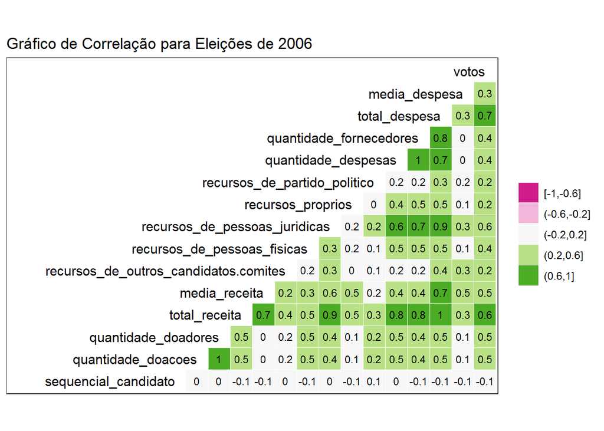

```r
require(GGally)

eleicoes_2006 %>%
  select(-partido,
         -uf,-nome,
         -estado_civil,
         -ocupacao,-ano,
         -total_recursos,
         -cargo,-grau,-sexo) %>%
  na.omit() %>%
  ggcorr(palette = "PiYG",
         color = "black",
         label = TRUE, hjust = 1,
         label_size = 3, size = 4,
         nbreaks = 5, layout.exp = 7) +
  ggtitle("Gráfico de Correlação para Eleições de 2006")
```

Acredito não ser plausível, visto que, por exemplo, **sequencial_candidato** possui valores muito baixos indicando uma correlação bem baixa com principalmente com a nossa variável resposta (votos). E de fato, o número sequencial do candidato não agrega em nada.

### 2010

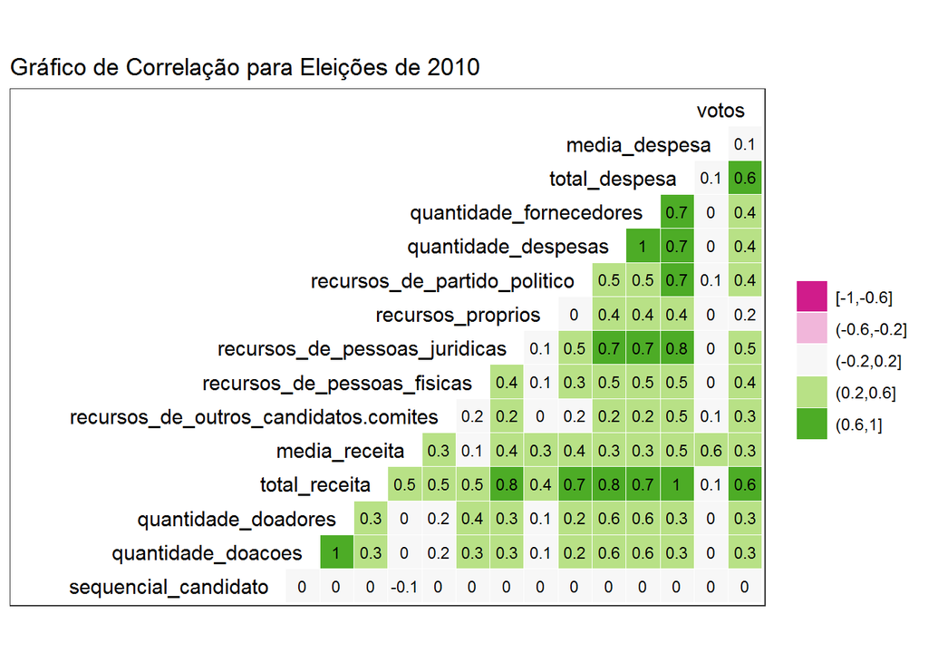

```r
require(GGally)

eleicoes_2010 %>%
  select(-partido,
         -uf,-nome,
         -estado_civil,
         -total_recursos,
         -ocupacao,-ano,
         -cargo,-grau,-sexo) %>%
  na.omit() %>%
  ggcorr(palette = "PiYG",
         color = "black",
         label = TRUE, hjust = 1,
         label_size = 3, size = 4,
         nbreaks = 5, layout.exp = 7) +
  ggtitle("Gráfico de Correlação para Eleições de 2010")
```

De forma análoga, **sequencial_candidato** não seria uma boa escolha e talvez para as eleições de 2010 os **recursos_proprios** não se apresentam com muito “peso” na nossa variável resposta.

```r
eleicoes_data %>% distinct(cargo)
```

```
## # A tibble: 1 x 1
##   cargo
##   <fct>
## 1 DEPUTADO FEDERAL
```

Em ambos os anos (2006 e 2010), a variável **cargo** não possui relevância pois todos são Deputados como podemos ver na tabela acima.

## 2 - Compare as regressões construídas para 2006 e 2010. Quais as diferenças/semelhanças percebidas?

### Preparando os dados…

Nessa etapa, iremos colocar as variáveis numéricas na mesma escala e adicionar mais um campo, o qual nos traz a informação dos recursos totais utilizados…

```r
eleicoes_data %>%
   mutate_at(.vars = vars(quantidade_doacoes,
                          quantidade_doadores,
                          total_recursos,
                          total_receita,
                          media_receita,
                          sequencial_candidato,
                          recursos_de_outros_candidatos.comites,
                          recursos_de_pessoas_fisicas,
                          recursos_de_pessoas_juridicas,
                          recursos_proprios,
                          recursos_de_partido_politico,
                          quantidade_despesas,
                          quantidade_fornecedores,
                          total_despesa,
                          media_despesa),
             .funs = funs(as.numeric(scale(.)))) -> eleicoes_gerais_escala

eleicoes_gerais_escala %>%
  sample_n(5)
```

```
## # A tibble: 5 x 25
##     ano sequencial_candid~ nome            uf    partido quantidade_doaco~
##   <int>              <dbl> <fct>           <fct> <fct>               <dbl>
## 1  2006             -0.930 JURACI VEIRA D~ CE    PL                 0.367
## 2  2010              0.786 ZACARIAS VILHA~ PE    PRB               -0.152
## 3  2006             -0.930 MARIA ASSUNÇÃO~ SP    PSDB              -0.0579
## 4  2010              0.180 AMOREZIO DIAS ~ MT    PTC               -0.228
## 5  2010              0.685 LUIZ JOSE DE B~ PR    PRB               -0.126
## # ... with 19 more variables: quantidade_doadores <dbl>,
## #   total_receita <dbl>, media_receita <dbl>,
## #   recursos_de_outros_candidatos.comites <dbl>,
## #   recursos_de_pessoas_fisicas <dbl>,
## #   recursos_de_pessoas_juridicas <dbl>, recursos_proprios <dbl>,
## #   recursos_de_partido_politico <dbl>, quantidade_despesas <dbl>,
## #   quantidade_fornecedores <dbl>, total_despesa <dbl>,
## #   media_despesa <dbl>, cargo <fct>, sexo <fct>, grau <fct>,
## #   estado_civil <fct>, ocupacao <fct>, votos <int>, total_recursos <dbl>
```

```r
eleicoes_2006 %>%
   mutate_at(.vars = vars(quantidade_doacoes,
                          quantidade_doadores,
                          total_recursos,
                          total_receita,
                          media_receita,
                          sequencial_candidato,
                          recursos_de_outros_candidatos.comites,
                          recursos_de_pessoas_fisicas,
                          recursos_de_pessoas_juridicas,
                          recursos_proprios,
                          recursos_de_partido_politico,
                          quantidade_despesas,
                          quantidade_fornecedores,
                          total_despesa,
                          media_despesa),
             .funs = funs(as.numeric(scale(.)))) -> eleicoes_2006_escala

eleicoes_2006_escala %>%
  sample_n(5)
```

```
## # A tibble: 5 x 25
##     ano sequencial_candid~ nome             uf    partido quantidade_doac~
##   <int>              <dbl> <fct>            <fct> <fct>              <dbl>
## 1  2006             -0.593 ANDRÉ CARLOS AL~ PE    PFL                6.08
## 2  2006              2.26  DANIELA PANDOLP~ SP    PSB               -0.391
## 3  2006              1.07  IRAJÁ FERREIRA ~ SP    PT DO B           -0.436
## 4  2006             -0.700 ERIVALDO COSTA ~ RN    PV                -0.436
## 5  2006              0.916 LUIS MAURO SANT~ RJ    PDT               -0.347
## # ... with 19 more variables: quantidade_doadores <dbl>,
## #   total_receita <dbl>, media_receita <dbl>,
## #   recursos_de_outros_candidatos.comites <dbl>,
## #   recursos_de_pessoas_fisicas <dbl>,
## #   recursos_de_pessoas_juridicas <dbl>, recursos_proprios <dbl>,
## #   recursos_de_partido_politico <dbl>, quantidade_despesas <dbl>,
## #   quantidade_fornecedores <dbl>, total_despesa <dbl>,
## #   media_despesa <dbl>, cargo <fct>, sexo <fct>, grau <fct>,
## #   estado_civil <fct>, ocupacao <fct>, votos <int>, total_recursos <dbl>
```

```r
eleicoes_2010 %>%
   mutate_at(.vars = vars(quantidade_doacoes,
                          quantidade_doadores,
                          total_recursos,
                          total_receita,
                          media_receita,
                          sequencial_candidato,
                          recursos_de_outros_candidatos.comites,
                          recursos_de_pessoas_fisicas,
                          recursos_de_pessoas_juridicas,
                          recursos_proprios,
                          recursos_de_partido_politico,
                          quantidade_despesas,
                          quantidade_fornecedores,
                          total_despesa,
                          media_despesa),
             .funs = funs(as.numeric(scale(.)))) -> eleicoes_2010_escala

eleicoes_2010_escala %>%
  sample_n(5)
```

```
## # A tibble: 5 x 25
##     ano sequencial_candid~ nome            uf    partido quantidade_doaco~
##   <int>              <dbl> <fct>           <fct> <fct>               <dbl>
## 1  2010              -1.31 ABEL SANT'ANNA~ ES    PV                0.258
## 2  2010              -2.17 JURANDIR BOIA ~ AL    PDT              -0.151
## 3  2010              -1.45 PAULO TADEU VA~ DF    PT                0.750
## 4  2010              -1.02 ORLANDO ARAUJO~ MA    PDT              -0.125
## 5  2010              -1.02 JOSÉ RIBAMAR C~ MA    PSB               0.00484
## # ... with 19 more variables: quantidade_doadores <dbl>,
## #   total_receita <dbl>, media_receita <dbl>,
## #   recursos_de_outros_candidatos.comites <dbl>,
## #   recursos_de_pessoas_fisicas <dbl>,
## #   recursos_de_pessoas_juridicas <dbl>, recursos_proprios <dbl>,
## #   recursos_de_partido_politico <dbl>, quantidade_despesas <dbl>,
## #   quantidade_fornecedores <dbl>, total_despesa <dbl>,
## #   media_despesa <dbl>, cargo <fct>, sexo <fct>, grau <fct>,
## #   estado_civil <fct>, ocupacao <fct>, votos <int>, total_recursos <dbl>
```

### 2006

```r
eleicoes_2006.lm <- lm(votos ~  partido * (total_receita + total_despesa + total_recursos) +
                                uf * (total_receita + total_despesa + total_recursos) +
                                (quantidade_doadores + quantidade_doacoes) +
                                (quantidade_despesas + quantidade_fornecedores),
          data = eleicoes_2006_escala)

broom::glance(eleicoes_2006.lm)
```

```
##   r.squared adj.r.squared    sigma statistic p.value  df   logLik     AIC
## 1 0.6454013     0.6212542 27986.19  26.72789       0 220 -39944.6 80331.2
##       BIC     deviance df.residual
## 1 81688.6 2.518857e+12        3216
```

Com o modelo utilizado nós conseguimos um R² de aproximadamente **64%** e um R² ajustado de aproximadamente **62%**. Ou seja, o nosso modelo consegue explicar bem o nosso conjunto de dados.

```r
eleicoes_2006.lm.res <- resid(eleicoes_2006.lm)
std.resid <- rstandard(eleicoes_2006.lm)
votos <- eleicoes_2006_escala$votos

resid_data_2006 <- data.frame(eleicoes_2006.lm.res, std.resid, votos,
                       stringsAsFactors = FALSE)
```

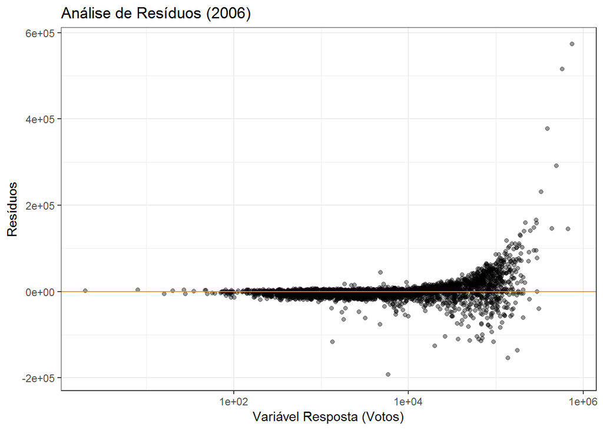

```r
resid_data_2006 %>%
  ggplot(aes(votos, eleicoes_2006.lm.res)) +
  geom_point(alpha = 0.4) +
  geom_hline(yintercept = 0,
             color = "darkorange") +
  labs(x = "Variável Resposta (Votos)", y = "Resíduos") +
  ggtitle("Análise de Resíduos (2006)") +
  scale_x_log10()
```

Com essa visualização para a análise de resíduos conseguimos perceber que o nosso modelo consegue se adequar/ajustar aos dados de uma forma convincente. Quando a quantidade de votos cresce muito para alguns deputados, o nosso modelo não consegue explicar o motivo do crescimento.

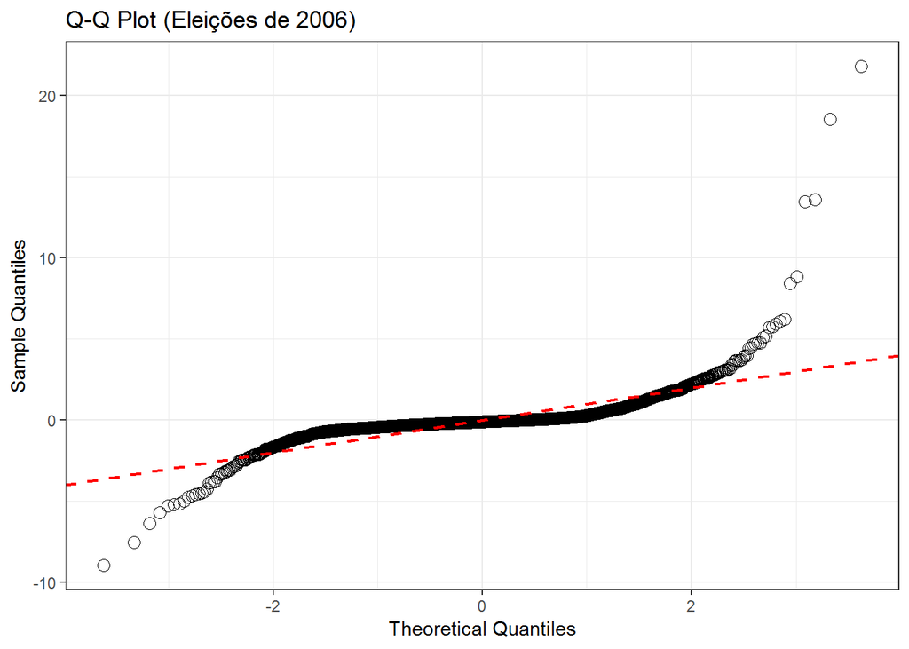

```r
eleicoes_2006.lm %>%
  ggplot(aes(sample = rstandard(.))) +
  stat_qq(na.rm = TRUE,
          shape = 1,
          size = 3) +
  labs(title="Q-Q Plot (Eleições de 2006)",
        x="Theoretical Quantiles",
        y="Sample Quantiles") +
  geom_abline(color = "red",
              size = 0.8,
              linetype="dashed")
```

### 2010

Repetindo o mesmo modelo para o ano de 2010…

```r
eleicoes_2010.lm <- lm(votos ~  partido * (total_receita + total_despesa + total_recursos) +
                                uf * (total_receita + total_despesa + total_recursos) +
                                (quantidade_doadores + quantidade_doacoes) +
                                (quantidade_despesas + quantidade_fornecedores),
          data = eleicoes_2010_escala)

broom::glance(eleicoes_2010.lm)
```

```
##   r.squared adj.r.squared    sigma statistic p.value  df   logLik     AIC
## 1 0.5837443     0.5605706 32851.69  25.18998       0 214 -47637.6 95705.2
##        BIC     deviance df.residual
## 1 97060.56 4.129147e+12        3826
```

Aplicando o mesmo modelo para as eleições de 2010 conseguimos perceber a primeira diferença no R², pois enquanto na de 2006 tínhamos um R² de aproximadamente **64%** aqui conseguimos aproximadamente **58%**. Uma diferença bastante considerável.

```r
eleicoes_2010.lm.res <- resid(eleicoes_2010.lm)
std.resid <- rstandard(eleicoes_2010.lm)
votos <- eleicoes_2010_escala$votos

resid_data_2010 <- data.frame(eleicoes_2010.lm.res, std.resid, votos,
                       stringsAsFactors = FALSE)
```

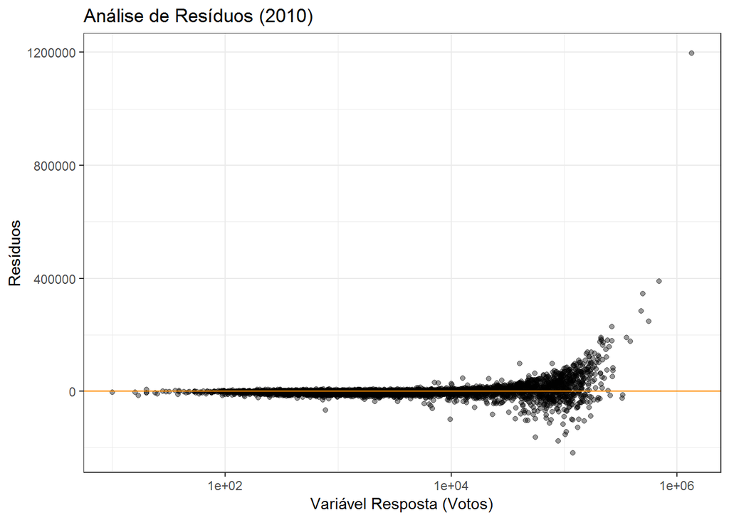

```r
resid_data_2010 %>%
  ggplot(aes(votos, eleicoes_2010.lm.res)) +
  geom_point(alpha = 0.4) +
  geom_hline(yintercept = 0,
             color = "darkorange") +
  labs(x = "Variável Resposta (Votos)", y = "Resíduos") +
  ggtitle("Análise de Resíduos (2010)") +
  scale_x_log10()
```

O mesmo modelo aplicado às eleições de 2010 parece se ajustar/adequar mais aos dados… Em uma dada quantidade de votos, na **Análise de Resíduos (2006)** os pontos parecem mais separados enquanto aqui eles ficam bem mais próximos à reta… O nosso conjunto de dados para o ano de 2010 possui mais observações, o que pode ter sido um fator que modificou a “eficiência” do modelo utilizado.

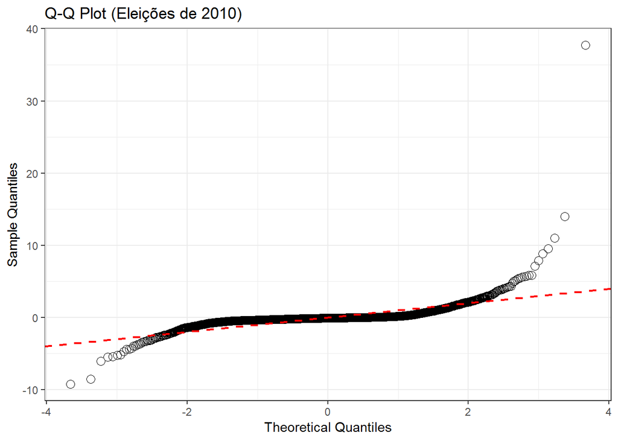

```r
eleicoes_2010.lm %>%
  ggplot(aes(sample = rstandard(.))) +
  stat_qq(na.rm = TRUE,
          shape = 1,
          size = 3) +
  labs(title="Q-Q Plot (Eleições de 2010)",
        x="Theoretical Quantiles",
        y="Sample Quantiles") +
  geom_abline(color = "red",
              size = 0.8,
              linetype="dashed")
```

Como esperado, o Q-Q Plot acima nos dá mais um indicativo da qualidade do nosso modelo. Aparentemente a reta vermelha pontilhada nessa visualização aparenta estar acompanhando a curva de forma mais “fiel” em relação à visualização do Q-Q Plot para 2006.

### Conclusão

Apesar de termos uma diferença grande no valor de R² para os dois conjuntos de dados, os plots para os resíduos de cada modelo parecem ter melhor “desempenho” para as eleições de 2010, pois aparentemente a reta está “seguindo” mais pontos, o que indica que temos um melhor ajuste em relação aos resíduos.

## 3 - Todas as variáveis são úteis para os modelos de regressão? Há variáveis redudantes? Faça análises para 2006 e 2010 separadamente.

Como já vimos na resposta para a questão 1, nem todas as variáveis são úteis…

### Redundância

Como já temos informações sobre despesas e receitas, talvez a informação da quantidade de fornecedores ou de despesas seja redundante para o nosso modelo…

### 2006

```r
input <- eleicoes_2006
input$sequencial_candidato <- as.numeric(as.factor(input$sequencial_candidato))
input$nome <- as.numeric(as.factor(input$nome))
input$uf <- as.numeric(as.factor(input$uf))
input$partido <- as.numeric(as.factor(input$partido))
input$cargo <- as.numeric(as.factor(input$cargo))
input$sexo <- as.numeric(as.factor(input$sexo))
input$grau <- as.numeric(as.factor(input$grau))
input$estado_civil <- as.numeric(as.factor(input$estado_civil))
input$ocupacao <- as.numeric(as.factor(input$ocupacao))
```

```r
model_2006_original <- lm(formula = votos ~ ., input, na.action = na.omit)

broom::glance(model_2006_original)
```

```
##   r.squared adj.r.squared    sigma statistic p.value df    logLik      AIC
## 1 0.5210894     0.5182847 31562.04  185.7884       0 21 -40460.91 80965.81
##        BIC     deviance df.residual
## 1 81100.94 3.401895e+12        3415
```

```r
model_2006_selected <- lm(formula = votos ~ ., input %>% select(-quantidade_despesas, -quantidade_fornecedores), na.action = na.omit)

broom::glance(model_2006_selected)
```

```
##   r.squared adj.r.squared    sigma statistic p.value df    logLik      AIC
## 1 0.5125873     0.5100197 31831.65  199.6381       0 19 -40491.14 81022.28
##        BIC     deviance df.residual
## 1 81145.12 3.462289e+12        3417
```

É possível perceber que o R² dos dois modelos ficou bem parecido… O que pode nos indicar de certa forma uma redundância.

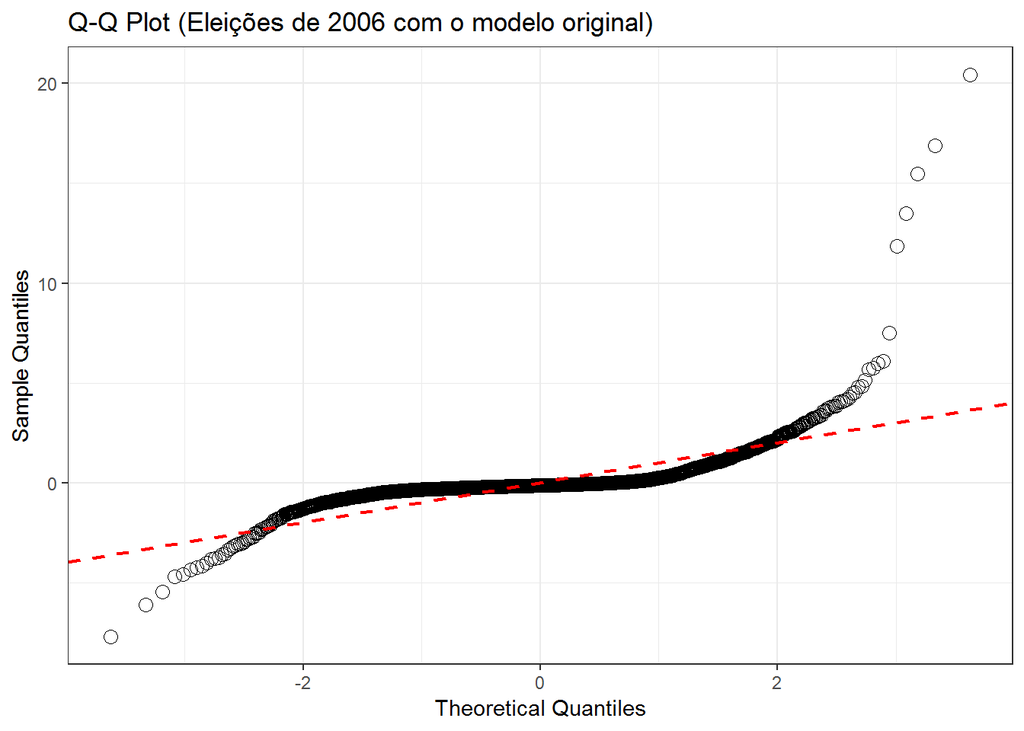

```r
model_2006_original %>%
  ggplot(aes(sample = rstandard(.))) +
  stat_qq(na.rm = TRUE,
          shape = 1,
          size = 3) +
  labs(title="Q-Q Plot (Eleições de 2006 com o modelo original)",
        x="Theoretical Quantiles",
        y="Sample Quantiles") +
  geom_abline(color = "red",
              size = 0.8,
              linetype="dashed")
```

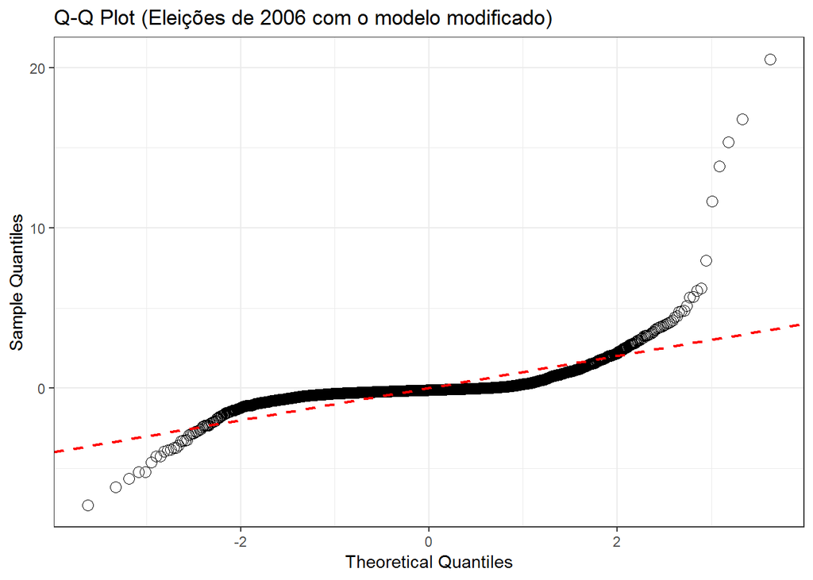

```r
model_2006_selected %>%
  ggplot(aes(sample = rstandard(.))) +
  stat_qq(na.rm = TRUE,
          shape = 1,
          size = 3) +
  labs(title="Q-Q Plot (Eleições de 2006 com o modelo modificado)",
        x="Theoretical Quantiles",
        y="Sample Quantiles") +
  geom_abline(color = "red",
              size = 0.8,
              linetype="dashed")
```

Ambos os Q-Q Plots nos possibilitam ver a adequação do modelo em relação aos dados e são bem parecidos. Ou seja, possívelmente essas duas variáveis de fato estejam resumidas nas outras variáveis que temos, possibilitando assim essa semelhança entre os modelos.

### 2010

```r
input <- eleicoes_2010
input$sequencial_candidato <- as.numeric(as.factor(input$sequencial_candidato))
input$nome <- as.numeric(as.factor(input$nome))
input$uf <- as.numeric(as.factor(input$uf))
input$partido <- as.numeric(as.factor(input$partido))
input$cargo <- as.numeric(as.factor(input$cargo))
input$sexo <- as.numeric(as.factor(input$sexo))
input$grau <- as.numeric(as.factor(input$grau))
input$estado_civil <- as.numeric(as.factor(input$estado_civil))
input$ocupacao <- as.numeric(as.factor(input$ocupacao))
```

```r
model_2010_original <- lm(formula = votos ~ ., input, na.action = na.omit)

broom::glance(model_2010_original)
```

```
##   r.squared adj.r.squared    sigma statistic p.value df    logLik      AIC
## 1 0.4420276     0.4392509 37110.55  159.1933       0 21 -48229.48 96502.95
##        BIC     deviance df.residual
## 1 96641.64 5.534939e+12        4019
```

```r
model_2010_selected <- lm(formula = votos ~ ., input %>% select(-quantidade_despesas, -quantidade_fornecedores), na.action = na.omit)

broom::glance(model_2010_selected)
```

```
##   r.squared adj.r.squared    sigma statistic p.value df    logLik      AIC
## 1 0.4374423      0.434924 37253.46  173.7062       0 19 -48246.01 96532.02
##       BIC     deviance df.residual
## 1 96658.1 5.580424e+12        4021
```

Como esperado, assim como em 2006, os modelos para as eleições obtiveram resultados semelhantes para o R², inclusive é um valor bem baixo, visto que não “explica” nem 50% dos dados.

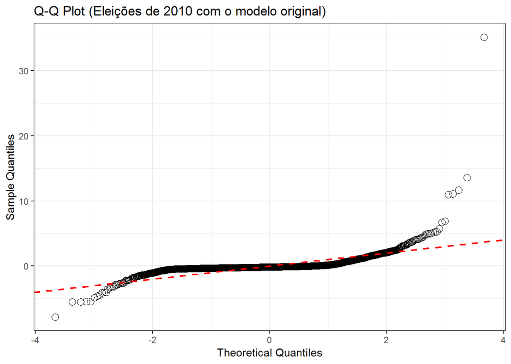

```r
model_2010_original %>%
  ggplot(aes(sample = rstandard(.))) +
  stat_qq(na.rm = TRUE,
          shape = 1,
          size = 3) +
  labs(title="Q-Q Plot (Eleições de 2010 com o modelo original)",
        x="Theoretical Quantiles",
        y="Sample Quantiles") +
  geom_abline(color = "red",
              size = 0.8,
              linetype="dashed")
```

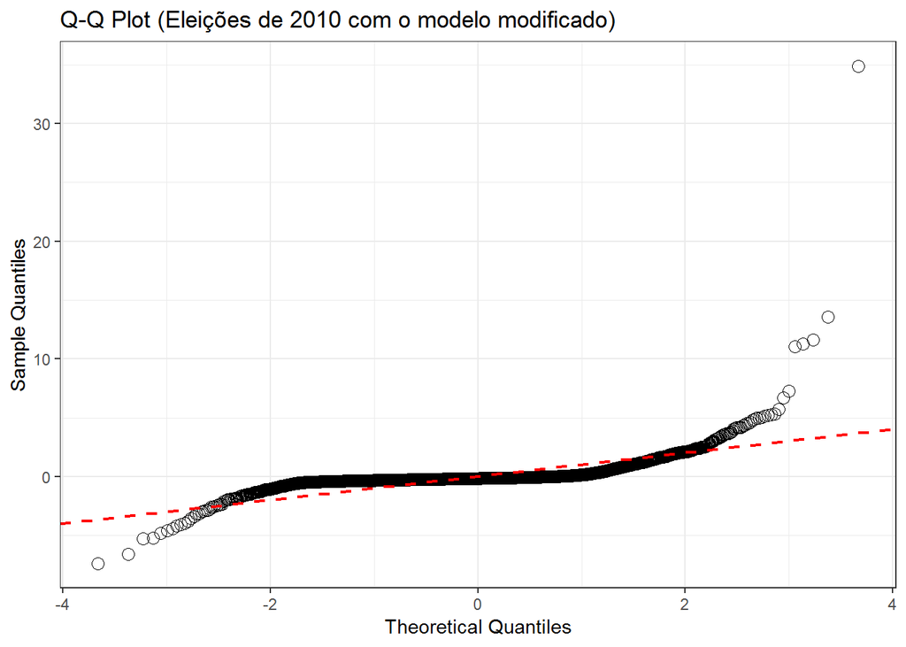

```r
model_2010_selected %>%
  ggplot(aes(sample = rstandard(.))) +
  stat_qq(na.rm = TRUE,
          shape = 1,
          size = 3) +
  labs(title="Q-Q Plot (Eleições de 2010 com o modelo modificado)",
        x="Theoretical Quantiles",
        y="Sample Quantiles") +
  geom_abline(color = "red",
              size = 0.8,
              linetype="dashed")
```

De forma análoga aos resultados obtidos nas visualizações para as eleições de 2006, as visualizações são bastante semelhantes… Nos possibilitando a hipótese de que as variáveis são, de certo modo, redundantes.

## 4 - No caso de haver variáveis pouco explicativas e/ou redudantes, construa um novo modelo sem essas variáveis e o compare ao modelo com todas as variáveis (e.g. em termos de R2 e RSE). Faça isso para 2006 e 2010 separadamente.

### quantidade_despesas / quantidade_fornecedores (2006)

Modificando o nosso modelo para retirar essas duas variáveis, obtemos o seguinte resultado:

```r
eleicoes_2006.lm.v2 <- lm(votos ~  partido * (total_receita + total_despesa + total_recursos) +
                                    uf * (total_receita + total_despesa + total_recursos) +
                                    (quantidade_doadores + quantidade_doacoes),
          data = eleicoes_2006_escala)

broom::glance(eleicoes_2006.lm.v2)
```

```
##   r.squared adj.r.squared sigma statistic p.value  df    logLik      AIC
## 1 0.6423655     0.6182491 28097  26.63601       0 218 -39959.25 80356.49
##       BIC     deviance df.residual
## 1 81701.6 2.540422e+12        3218
```

De forma semelhante ao resultado do modelo da questão 2, o nosso R² obteve um valor de aproximadamente **64%**. Ou seja, para o nosso modelo e nosso conjunto de dados as variáveis sobre as quantidades de despesas e fornecedores são redundantes, pois provavelmente já são “explicadas” indiretamente no total de receitas, despesas e recursos.

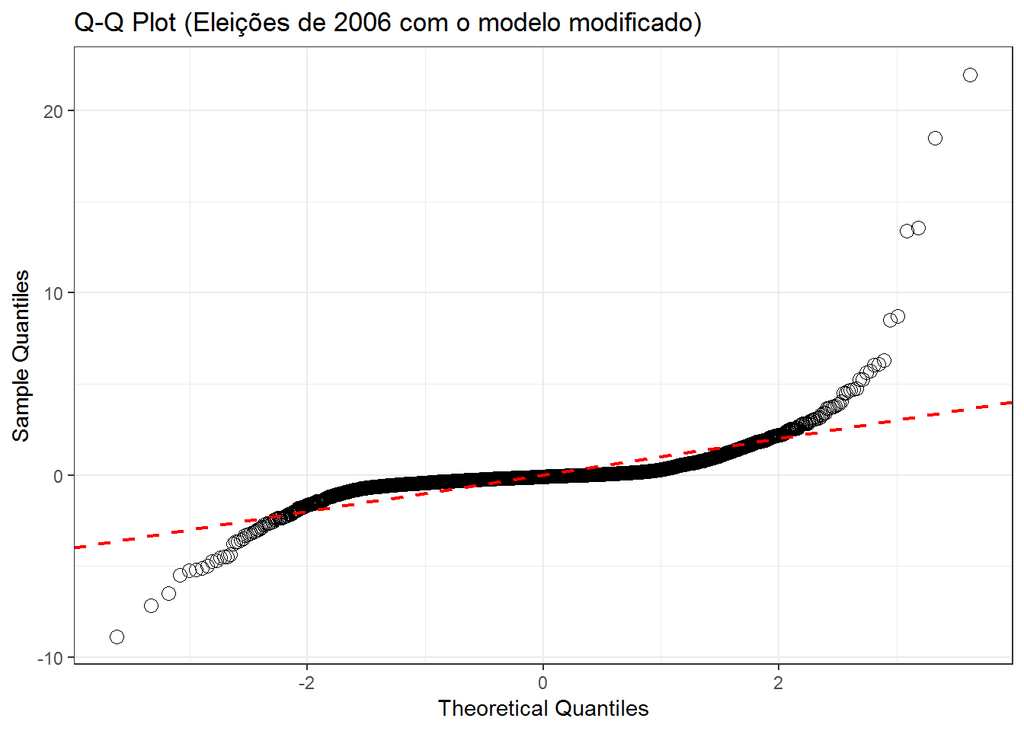

```r
eleicoes_2006.lm.v2 %>%
  ggplot(aes(sample = rstandard(.))) +
  stat_qq(na.rm = TRUE,
          shape = 1,
          size = 3) +
  labs(title="Q-Q Plot (Eleições de 2006 com o modelo modificado)",
        x="Theoretical Quantiles",
        y="Sample Quantiles") +
  geom_abline(color = "red",
              size = 0.8,
              linetype="dashed")
```

O Q-Q Plot parece bem semelhante ao que vimos na questão 2.

### Conclusão

Tanto os valores do R² como os plots para os resíduos apresentam valores e visualizações semelhantes ao que vimos no modelo original descrito na questão 2. Portanto, a partir dessas informações, podemos dizer que para o conjunto de dados das eleições de 2006, as duas variáveis são redundantes.

### quantidade_despesas / quantidade_fornecedores (2010)

De forma análoga…

```r
eleicoes_2010.lm.v2 <- lm(votos ~  partido * (total_receita + total_despesa + total_recursos) +
                                    uf * (total_receita + total_despesa + total_recursos) +
                                    (quantidade_doadores + quantidade_doacoes),
                          data = eleicoes_2010_escala)

broom::glance(eleicoes_2010.lm.v2)
```

```
##   r.squared adj.r.squared    sigma statistic p.value  df    logLik
## 1 0.5835256     0.5605695 32851.73  25.41916       0 212 -47638.66
##        AIC      BIC     deviance df.residual
## 1 95703.32 97046.07 4.131316e+12        3828
```

Como esperado, os valores são bastante semelhantes ao do modelo original utilizado na questão 2.

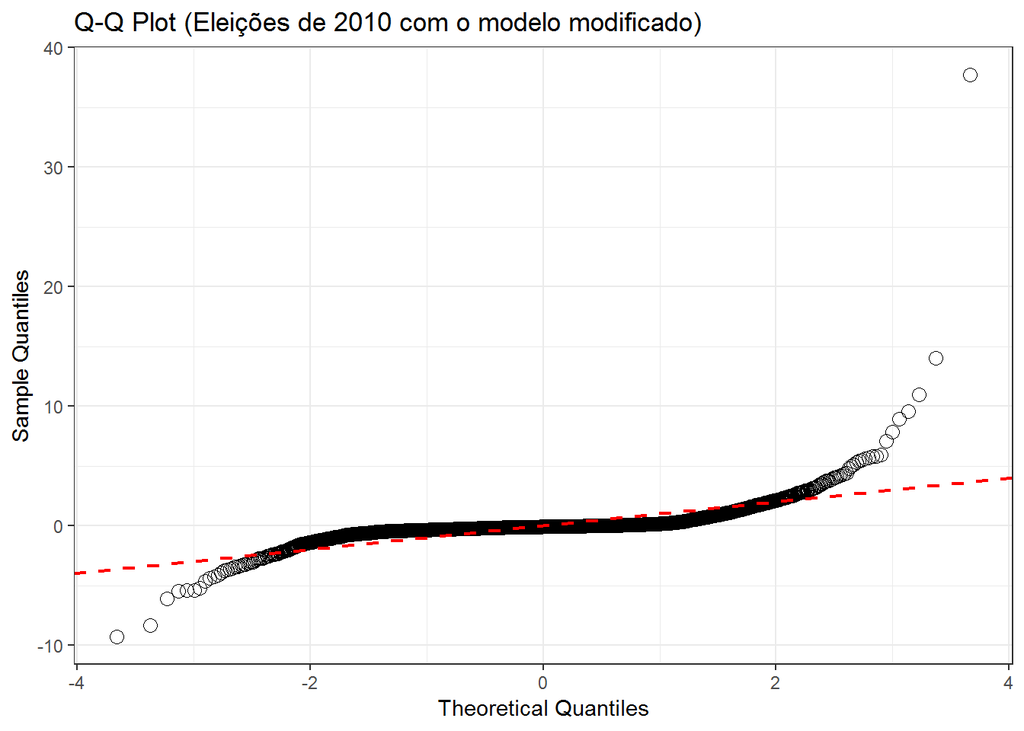

```r
eleicoes_2010.lm.v2 %>%
  ggplot(aes(sample = rstandard(.))) +
  stat_qq(na.rm = TRUE,
          shape = 1,
          size = 3) +
  labs(title="Q-Q Plot (Eleições de 2010 com o modelo modificado)",
        x="Theoretical Quantiles",
        y="Sample Quantiles") +
  geom_abline(color = "red",
              size = 0.8,
              linetype="dashed")
```

O Q-Q Plot para o novo modelo parece muito com o que vimos mais acima na questão anterior.

### Conclusão

De forma análoga à conclusão do modelo com dados de 2006, aqui também temos o mesmo resultado obtido… Tanto para o R² como para o Q-Q plot.

## 5 - Construa agora uma regressão considerando os anos 2006 e 2010 em conjunto. Que diferenças/semelhanças você percebe em relação aos modelos individuais por ano? Veja a questão 2 para sugestões que você usar para comparação.

```r
eleicoes_gerais.lm <- lm(votos ~  partido * (total_receita + total_despesa + total_recursos) +
                                    uf * (total_receita + total_despesa + total_recursos) +
                                    (quantidade_doadores + quantidade_doacoes),
          data = eleicoes_gerais_escala)

broom::glance(eleicoes_gerais.lm)
```

```
##   r.squared adj.r.squared    sigma statistic p.value  df    logLik
## 1 0.5412142     0.5267149 32831.98  37.32691       0 230 -88235.29
##        AIC    BIC     deviance df.residual
## 1 176932.6 178531 7.810744e+12        7246
```

```r
eleicoes_gerais.lm.res <- resid(eleicoes_gerais.lm)
std.resid <- rstandard(eleicoes_gerais.lm)
votos <- eleicoes_gerais_escala$votos

resid_data_geral <- data.frame(eleicoes_gerais.lm.res, std.resid, votos,
                       stringsAsFactors = FALSE)
```

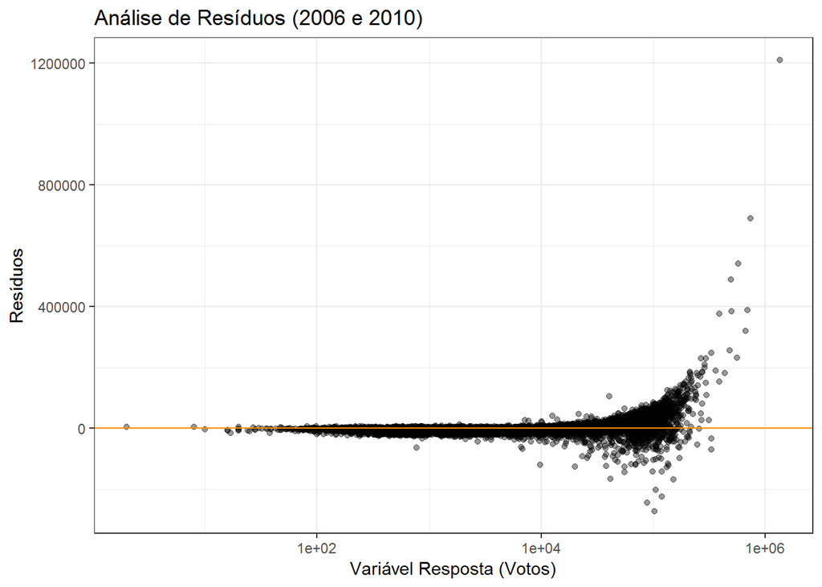

```r
resid_data_geral %>%
  ggplot(aes(votos, eleicoes_gerais.lm.res)) +
  geom_point(alpha = 0.4) +
  geom_hline(yintercept = 0,
             color = "darkorange") +
  labs(x = "Variável Resposta (Votos)", y = "Resíduos") +
  ggtitle("Análise de Resíduos (2006 e 2010)") +
  scale_x_log10()
```

Com essa análise dos anos de 2006 e 2010 conseguimos perceber também que o nosso modelo consegue se ajustar/adequar a boa parte dos dados, como vimos pelo valor do R², embora haja uma perda quando a quantidade de votos começa a aumentar.

Podemos entender assim que quando os dados são mesclados, o nosso modelo consegue generalizar bem, pois mesmo com uma quantidade maior de observações, o nosso modelo obteve um resultado semelhante aos que fizemos para cada ano separadamente, conseguindo explicar mais de 50% dos dados e tendo uma adequação até uma certa quantidade de votos.

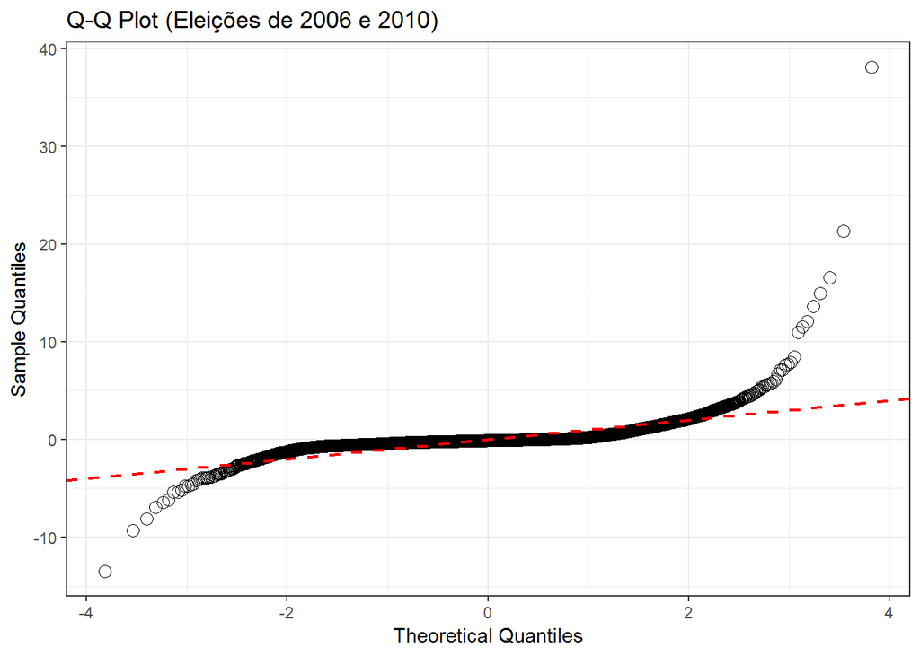

```r
eleicoes_gerais.lm %>%
  ggplot(aes(sample = rstandard(.))) +
  stat_qq(na.rm = TRUE,
          shape = 1,
          size = 3) +
  labs(title="Q-Q Plot (Eleições de 2006 e 2010)",
        x="Theoretical Quantiles",
        y="Sample Quantiles") +
  geom_abline(color = "red",
              size = 0.8,
              linetype="dashed")
```